# liz Analysis

```r
rm(list=ls())
library(plyr) # used for "round_any" fuctnion
library(dplyr)
library(tidyverse)
library(lme4)
```

# Create unfiltered data frame

## read in and merge files

```r
setwd("C:/Users/liz/OneDrive - Nexus365/Eva_Liz_Leverhulme/leverhulmeNDL/eyetracker - fribbles/preProcessed_data")
pilot1 = read.csv("pilot1/eyeTracker_intersections.csv")
pilot2 = read.csv("pilot2/eyeTracker_intersections.csv")
pilot1$pilotgroup = "pilot1"
pilot2$pilotgroup = "pilot2"
pilot1$list = 1 # there is no column for this in the original sheet
bothpilot= rbind(pilot1,pilot2)

# Add in information about looks to target and different foil types

#Using a table, add in 3 columns columns  $targetLocation $ mismatch1Location $mismatch2Location - which give the poistion (r/l/c) where the targets two #different foil types are respective (for control trials, the last two columns are NA)

listsTable = read.csv("listsTable.csv")
bothpilot = merge(bothpilot,listsTable, by =c("list","frequency","labelPresented"))
# note: the column position codes where the target is for the foil in both pilot data sets
bothpilot$targetLocation[bothpilot$frequency == "control"]=bothpilot$position[bothpilot$frequency == "control"]
table(bothpilot$position==bothpilot$targetLocation) # a double check -  pilot 2 already contained target location in the position column, this is now redundant
```

```
  TRUE
233010
```

```r
bothpilot$position=NULL

bothpilot = as.data.frame(unclass(bothpilot), stringsAsFactors= TRUE)# turn all character columns into factors
bothpilot$list = as.factor(bothpilot$list)
bothpilot$subjID = as.factor(bothpilot$subjID)

bothpilot$subjID.trial = as.factor(paste(bothpilot$subjID, bothpilot$trial))

# for control trials, randomly assign those on left/right/center as foil1/foil2
## first create randomizer table with ranomdly 1/2 for every participant/trial combination
randomizerTable = data.frame(cbind(levels(bothpilot$subjID.trial), sample(1:2, length(levels(bothpilot$subjID.trial)), replace=T)))
colnames(randomizerTable) = c("subjID.trial","randomizer" )
randomizerTable$subjID.trial= as.factor(randomizerTable$subjID.trial)
randomizerTable$randomizer= as.numeric(randomizerTable$randomizer)
## merge info from randomizer table into dataframe so have a column called randomizer and use it to assign positions for foil1 and foil2
dim(bothpilot)
```

```
[1] 399916     27
```

```r
bothpilot = merge(bothpilot, randomizerTable)
dim(bothpilot)
```

```
[1] 399916     28
```

```r
bothpilot$Foil1Location = NA
bothpilot$Foil2Location = NA

bothpilot$Foil1Location[bothpilot$frequency=="control" & bothpilot$targetLocation=="r" & bothpilot$randomizer==1] = "l"
bothpilot$Foil1Location[bothpilot$frequency=="control" & bothpilot$targetLocation=="r" & bothpilot$randomizer==2] = "c"
bothpilot$Foil1Location[bothpilot$frequency=="control" & bothpilot$targetLocation=="l" & bothpilot$randomizer==1] = "c"
bothpilot$Foil1Location[bothpilot$frequency=="control" & bothpilot$targetLocation=="l" & bothpilot$randomizer==2] = "r"
bothpilot$Foil1Location[bothpilot$frequency=="control" & bothpilot$targetLocation=="c" & bothpilot$randomizer==1] = "r"
bothpilot$Foil1Location[bothpilot$frequency=="control" & bothpilot$targetLocation=="c" & bothpilot$randomizer==2] = "l"

bothpilot$Foil2Location[bothpilot$frequency=="control" & bothpilot$targetLocation=="r" & bothpilot$randomizer==1] = "c"
bothpilot$Foil2Location[bothpilot$frequency=="control" & bothpilot$targetLocation=="r" & bothpilot$randomizer==2] = "l"
bothpilot$Foil2Location[bothpilot$frequency=="control" & bothpilot$targetLocation=="l" & bothpilot$randomizer==1] = "r"
bothpilot$Foil2Location[bothpilot$frequency=="control" & bothpilot$targetLocation=="l" & bothpilot$randomizer==2] = "c"
bothpilot$Foil2Location[bothpilot$frequency=="control" & bothpilot$targetLocation=="c" & bothpilot$randomizer==1] = "l"
bothpilot$Foil2Location[bothpilot$frequency=="control" & bothpilot$targetLocation=="c" & bothpilot$randomizer==2] = "r"



#table(bothpilot$targetLocation,bothpilot$randomizer)

#bothpilot$targetLocation
```

## add looking time columns

Add the key columns $targetLabelLk $mismatch1LabelLk $mismatch2LabelLk $rControlFoilLk $lControlFoilLk $cControlFoilLk which are using in plotting/analyses of looking time

```r
#set up empty columns
bothpilot$targetLabelLk= NA
bothpilot$mismatch1LabelLk= NA
bothpilot$mismatch2LabelLk= NA
#bothpilot$ControlBothFoilLk= NA
#bothpilot$ControlOneFoilLk= NA
bothpilot$ControlFoil1Lk= NA
bothpilot$ControlFoil2Lk= NA

# add columns with looks to target
bothpilot$targetLabelLk[bothpilot$targetLocation=="r"] = bothpilot$rLabel[bothpilot$targetLocation=="r"]
bothpilot$targetLabelLk[bothpilot$targetLocation=="l"] = bothpilot$lLabel[bothpilot$targetLocation=="l"]
bothpilot$targetLabelLk[bothpilot$targetLocation=="c"] = bothpilot$cLabel[bothpilot$targetLocation=="c"]

# add columns with looks to mismatch type 1 (this will only match for non control trials)
f=bothpilot$mismatch1Location=="r" & bothpilot$frequency != "control"
bothpilot$mismatch1LabelLk[f] = bothpilot$rLabel[f]
f=bothpilot$mismatch1Location=="l" & bothpilot$frequency != "control"
bothpilot$mismatch1LabelLk[f] = bothpilot$lLabel[f]
f=bothpilot$mismatch1Location=="c" & bothpilot$frequency != "control"
bothpilot$mismatch1LabelLk[f] = bothpilot$cLabel[f]
# add columns with looks to mismatch type 2 (this will only match for non control trials)
f=bothpilot$mismatch2Location=="r" & bothpilot$frequency != "control"
bothpilot$mismatch2LabelLk[f] = bothpilot$rLabel[f]
f=bothpilot$mismatch2Location=="l" & bothpilot$frequency != "control"
bothpilot$mismatch2LabelLk[f] = bothpilot$lLabel[f]
f=bothpilot$mismatch2Location=="c" & bothpilot$frequency != "control"
bothpilot$mismatch2LabelLk[f] = bothpilot$cLabel[f]

# add columns with looks to control1 (this will only match for  control trials)
f=bothpilot$Foil1Location=="r" & bothpilot$frequency == "control"
bothpilot$ControlFoil1Lk[f] = bothpilot$rLabel[f]
f=bothpilot$Foil1Location=="l" & bothpilot$frequency == "control"
bothpilot$ControlFoil1Lk[f] = bothpilot$lLabel[f]
f=bothpilot$Foil1Location=="c" & bothpilot$frequency == "control"
bothpilot$ControlFoil1Lk[f] = bothpilot$cLabel[f]
# add columns with looks to control2 (this will only match for  control trials)
f=bothpilot$Foil2Location=="r" & bothpilot$frequency == "control"
bothpilot$ControlFoil2Lk[f] = bothpilot$rLabel[f]
f=bothpilot$Foil2Location=="l" & bothpilot$frequency == "control"
bothpilot$ControlFoil2Lk[f] = bothpilot$lLabel[f]
f=bothpilot$Foil2Location=="c" & bothpilot$frequency == "control"
bothpilot$ControlFoil2Lk[f] = bothpilot$cLabel[f]


#control foils
#f = bothpilot$frequency == "control" & bothpilot$targetLocation=="r"
#bothpilot$ControlBothFoilLk[f] = (bothpilot$lLabel[f]+bothpilot$cLabel[f])
#bothpilot$lControlFoilLk[f] = bothpilot$lLabel[f]
#bothpilot$cControlFoilLk[f] = bothpilot$cLabel[f]

# add columns with looks to foils in right position
#f = bothpilot$frequency == "control" & bothpilot$targetLocation=="l"
#bothpilot$ControlBothFoilLk[f] = (bothpilot$rLabel[f]+bothpilot$cLabel[f])
#bothpilot$rControlFoilLk[f] = bothpilot$rLabel[f]
#bothpilot$cControlFoilLk[f] = bothpilot$cLabel[f]
# add columns with looks to foils in left position
#f = bothpilot$frequency == "control" & bothpilot$targetLocation=="c"
#bothpilot$ControlBothFoilLk[f] = (bothpilot$rLabel[f]+bothpilot$lLabel[f])
#bothpilot$rControlFoilLk[f] = bothpilot$rLabel[f]
#bothpilot$lControlFoilLk[f] = bothpilot$lLabel[f]

# add column with 0.5 (rather than 1) if they look at one of the foils - this is used for plotting proportions when comparing against the two conditions where there are two different foils so that chance of looking is average chance fo looking at one of the foils

#bothpilot$ControlOneFoilLk = bothpilot$ControlBothFoilLk/2
```

## add in column for block

```r
bothpilot$block = 0
bothpilot$block[bothpilot$trial >=10 & bothpilot$trial <= 39] = 1
bothpilot$block[bothpilot$trial >=41 & bothpilot$trial <= 65] = 2
bothpilot$block[bothpilot$trial >=67 & bothpilot$trial <= 92] = 3
bothpilot$block[bothpilot$trial >=94 & bothpilot$trial <= 122] = 4
bothpilot$block[bothpilot$trial >=124 & bothpilot$trial <= 149] = 5
bothpilot$block[bothpilot$trial >=151 & bothpilot$trial <= 174] = 6

#check the ranges are as expected correct
range(subset(bothpilot, block == 1)$trial)
```

```
[1] 10 39
```

```r
range(subset(bothpilot, block == 2)$trial)
```

```
[1] 41 65
```

```r
range(subset(bothpilot, block == 3)$trial)
```

```
[1] 67 92
```

```r
range(subset(bothpilot, block == 4)$trial)
```

```
[1]  94 122
```

```r
range(subset(bothpilot, block == 5)$trial)
```

```
[1] 124 149
```

```r
range(subset(bothpilot, block == 6)$trial)
```

```
[1] 151 174
```

## double check coding of columns for looks

Code chunk in this section currently commenting out (add back in by highlighting whole chunk and using ctr+shif+c. Note it doesn’t add anything, but double checks the column for looks added above is correct. I basically went through it bit by bit, checking against the table of values I had.

Eva - note that I created this before you shared the syntax for filtering and sharing in the package. The following are equivlaent:

x = subset(bothpilot, list ==1&labelPresented==“dep”) table(x$targetLocation)

could be written

bothpilot%>% filter( list ==1&labelPresented==“dep”) %>% count(targetLocation)

I am not sure how to get table(x$targetLabelLk==x$cLabel) using the plr syntax. But what it does is check if, in the filtered data set, counts the number of rows where it is TRUE that the column targetLabelLk is equivalent to the column cLabel, and the number of rows where it that false. You can see that it is always TRUE. It returns “TRUE 69909”- indicating that only TRUE values are found (69909 of them). I am sure there is a much neater way to do this, but I did find a few errors this way.

# checking for missing data and filtering

check have the expected number of trials per block in each list

```r
bothpilot %>%
  group_by(block, frequency, list) %>%
  summarise(n_distinct(trial))%>%
  pivot_wider(names_from = c(list), values_from = `n_distinct(trial)`)
```

| block | frequency | 1 | 2 | 3 |
| --- | --- | --- | --- | --- |
| 1 | control | 5 | 8 | 10 |
| 1 | h | 19 | 17 | 16 |
| 1 | l | 6 | 5 | 4 |
| 2 | control | 7 | 3 | 9 |
| 2 | h | 13 | 16 | 12 |
| 2 | l | 5 | 6 | 4 |
| 3 | control | 8 | 8 | 4 |
| 3 | h | 12 | 12 | 17 |
| 3 | l | 6 | 6 | 5 |
| 4 | control | 6 | 4 | 7 |

[output cut: 8 more lines]

Checking for participant trial combinations where whole trials are missing:

```r
table = table(bothpilot$trial, bothpilot$subjID) # creates a table with trial numbers as rows and participants as columns and number of rows in data which match this criteria - where there is a zero the trial must be missing
df = data.frame(table) ## turn into a dataframe
colnames(df) = c("trial","subjID","Freq")

wholeTrial.Missing = subset(df, Freq ==0 ) ## view the participant + trial number with missing data
wholeTrial.Missing
```

|  | trial | subjID | Freq |
| --- | --- | --- | --- |
| 10 | 19 | 3394859 | 0 |

```r
100*(nrow(wholeTrial.Missing)/nrow(df)) ## percentage whole trials missing
```

```
[1] 0.03289474
```

Checking for trials with no data for screen index 2,3,4

```r
df.screen2 = data.frame(table(subset(bothpilot, screen_index ==2)$trial, subset(bothpilot, screen_index ==2)$subjID)) # same logic as above chunk,  for screen 2
df.screen3 = data.frame(table(subset(bothpilot, screen_index ==3)$trial, subset(bothpilot, screen_index ==3)$subjID)) # same logic as above chunk,  for screen 3
df.screen4 = data.frame(table(subset(bothpilot, screen_index ==4)$trial, subset(bothpilot, screen_index ==4)$subjID)) # same logic as above chunk,  for screen 4

df.screen2$missing = "screen2"
df.screen3$missing = "screen3"
df.screen4$missing = "screen4"

d.screen.missing = subset(rbind(df.screen2,df.screen3,df.screen4), Freq ==0 )
colnames(d.screen.missing ) = c("trial","subjID","Freq","whichScreen")
scene.Missing = subset(d.screen.missing, Freq ==0 ) ## view the participant + trial number with missing data

scene.Missing # view it so that you can see which screens have which missing
```

|  | trial | subjID | Freq | whichScreen |
| --- | --- | --- | --- | --- |
| 10 | 19 | 3394859 | 0 | screen2 |
| 2367 | 140 | 3518198 | 0 | screen2 |
| 2581 | 30 | 3528247 | 0 | screen2 |
| 2582 | 31 | 3528247 | 0 | screen2 |
| 3050 | 19 | 3394859 | 0 | screen3 |
| 5609 | 18 | 3528247 | 0 | screen3 |
| 6090 | 19 | 3394859 | 0 | screen4 |

```r
scene.Missing =distinct(scene.Missing) ### remove duplicates - i.e. trials where same particiapant + trial has more than one missing scene, will also include whole trial

scene.Missing$whichScreen = NULL

100*(nrow(scene.Missing)/nrow(df)) ## percentage trials where one or more of scenes missing (include those where all missing)
```

```
[1] 0.2302632
```

#remove participants+ trial combinations where we saw above that data was missing from one of the screens for that trial

```r
scene.Missing$subjID.trial = as.factor(paste(scene.Missing$subjID, scene.Missing$trial))
#bothpilot$subjID.trial = as.factor(paste(bothpilot$subjID, bothpilot$trial))

bothpilot.f1= bothpilot

subjTrial= levels(scene.Missing$subjID.trial)[1]
for (subjTrial in levels(scene.Missing$subjID.trial)){
  bothpilot.f1 = droplevels(subset(bothpilot.f1,subjID.trial != subjTrial))

}

dim(bothpilot.f1)
```

```
[1] 399597     36
```

```r
dim(bothpilot)
```

```
[1] 399916     36
```

```r
#for checking purposes, see who is removed
df  = data.frame(table(bothpilot.f1$trial, bothpilot.f1$subjID))
df = data.frame(table) ## turn into a dataframe
colnames(df) = c("trial","subjID","Freq")
subset(df, Freq ==0 ) ## view the participant + trial number with missing data
```

|  | trial | subjID | Freq |
| --- | --- | --- | --- |
| 10 | 19 | 3394859 | 0 |

```r
## note it matches what we saw above
```

# find participants+trials where timing isn’t accurate

add a column with value 1 when is last time point for the current screen

```r
bothpilot.f1=bothpilot.f1[order(bothpilot.f1$subjID,

                   bothpilot.f1$trial,
                   bothpilot.f1$screen_index,
                   bothpilot.f1$time  ),]


orginN = length(levels(bothpilot$subjID.trial))
newN= length(levels(bothpilot.f1$subjID.trial))

bothpilot.f1$lastTrialInScreen= 0
#row=3
for (row in 2:(nrow(bothpilot.f1)-1)){
  if(bothpilot.f1$screen_index[row] !=  bothpilot.f1$screen_index[row+1] ){bothpilot.f1$lastTrialInScreen[row]=1}
     }
sum(subset(bothpilot.f1, screen_index ==2)$lastTrialInScreen)==newN ## checking that sums to one trial marked as last in scene per partbytrial
```

```
[1] TRUE
```

```r
sum(subset(bothpilot.f1, screen_index ==3)$lastTrialInScreen)==newN
```

```
[1] TRUE
```

```r
sum(subset(bothpilot.f1, screen_index ==4)$lastTrialInScreen)==newN
```

```
[1] TRUE
```

```r
## get lists of trials+participants where the legnth of scenes 2, 3 and 4 are more than more than 100ms too short OR  too long for scenes  2 and 3 (for scene 4 we can cut it off)

screen2_tooshort = droplevels(subset(bothpilot.f1, screen_index==2 & lastTrialInScreen==1 & time < 300))
screen2_toolong = droplevels(subset(bothpilot.f1, screen_index==2 & lastTrialInScreen==1 & time > 400))
screen3_tooshort = droplevels(subset(bothpilot.f1, screen_index==3 & lastTrialInScreen==1 & time < 200))
screen3_toolong = droplevels(subset(bothpilot.f1, screen_index==3 & lastTrialInScreen==1 & time > 300))
screen4_tooshort = droplevels(subset(bothpilot.f1, screen_index==4 & lastTrialInScreen==1 & time < 1050))


list.wrongLength =c(levels(screen2_tooshort$subjID.trial),
  levels(screen2_toolong$subjID.trial),
  levels(screen3_tooshort$subjID.trial),
  levels(screen3_toolong$subjID.trial),
  levels(screen4_tooshort$subjID.trial))

length(list.wrongLength)
```

```
[1] 1157
```

```r
length(unique(list.wrongLength))/newN # proportion of trials to exclude
```

```
[1] 0.1835255
```

remove the trials where any scene was too long/short

```r
#list.wrongLength = as.factor(list.wrongLength)

bothpilot.f2= bothpilot.f1

#subjTrial= list.wrongLength[1]
for (subjTrial in list.wrongLength){
  bothpilot.f2 = droplevels(subset(bothpilot.f2,subjID.trial != subjTrial))

}

#check - these are now correct, except for 4 where we will be cutting them off
range(subset(bothpilot.f2, screen_index ==2 & lastTrialInScreen ==1)$time)
```

```
[1] 300.00 398.97
```

```r
range(subset(bothpilot.f2, screen_index ==3 & lastTrialInScreen ==1)$time)
```

```
[1] 200.065 299.305
```

```r
range(subset(bothpilot.f2, screen_index ==4 & lastTrialInScreen ==1)$time)
```

```
[1] 1050.550 1491.785
```

```r
NA
NA
```

# Additional columns used across plotting and analyses (binned time relative to fribble offset and 3 blocks)

```r
bothpilot.f2$timeRel = NA
bothpilot.f2$timeRel[bothpilot.f2$screen_index==3]= bothpilot.f2$time[bothpilot.f2$screen_index==3]
bothpilot.f2$timeRel[bothpilot.f2$screen_index==4]= bothpilot.f2$time[bothpilot.f2$screen_index==4]+300
bin = 50
bothpilot.f2$timeRel.bin = round_any(bothpilot.f2$timeRel, bin, f= ceiling)
```

```r
bothpilot.f2$block3 = 1
bothpilot.f2$block3[bothpilot.f2$block >2]= 2
bothpilot.f2$block3[bothpilot.f2$block >4]= 3
table(bothpilot.f2$block,bothpilot.f2$block3)
```

```
        1     2     3
  1 70527     0     0
  2 56972     0     0
  3     0 58761     0
  4     0 64906     0
  5     0     0 56777
  6     0     0 52841
```

# Plots

Plot 1- plotting proportion of looks to each

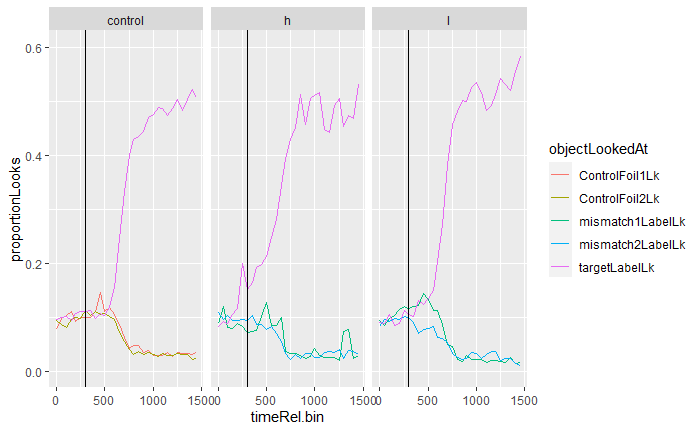

```r
#bothpilot.f2.long = gather(bothpilot.f2, objectLookedAt, proportionLooks, targetLabelLk:mismatch2LabelLk, ControlOneFoilLk )

bothpilot.f2.long = gather(bothpilot.f2, objectLookedAt, proportionLooks, targetLabelLk:mismatch2LabelLk, ControlFoil1Lk,ControlFoil2Lk )
bothpilot.f2.long$Location=NA

f=bothpilot.f2.long$objectLookedAt=="targetLabelLk"
bothpilot.f2.long$Location[f]=bothpilot.f2.long$targetLocation[f]

f=bothpilot.f2.long$objectLookedAt=="mismatch1LabelLk"
bothpilot.f2.long$Location[f]=bothpilot.f2.long$mismatch1Location[f]
f=bothpilot.f2.long$objectLookedAt=="mismatch2LabelLk"
bothpilot.f2.long$Location[f]=bothpilot.f2.long$mismatch2Location[f]

f=bothpilot.f2.long$objectLookedAt=="ControlFoil1Lk"
bothpilot.f2.long$Location[f]=bothpilot.f2.long$Foil1Location[f]
f=bothpilot.f2.long$objectLookedAt=="ControlFoil2Lk"
bothpilot.f2.long$Location[f]=bothpilot.f2.long$Foil2Location[f]

agg1= aggregate(data = subset(bothpilot.f2.long, screen_index==3|screen_index==4),
                             proportionLooks~ objectLookedAt+timeRel.bin + frequency + subjID +Location , FUN= mean)
agg2= aggregate(data = agg1, proportionLooks~ objectLookedAt +timeRel.bin + frequency + subjID, FUN= mean)
agg3= aggregate(data = agg2, proportionLooks~ objectLookedAt+timeRel.bin + frequency, FUN= mean)


p2= ggplot(agg3, aes(x=timeRel.bin, y=proportionLooks)) + geom_line(aes(color= objectLookedAt))
p2= p2 + geom_vline(xintercept= 300)
p2= p2 + ylim(0,.6)
p2 = p2 + xlim(0,1450)
p2= p2+facet_wrap(~frequency)
p2
```

```r
#log_odd<-function(p) {log(p/(1-p))}
```

Plotting proportion of looks to each split by blocks:

```r
agg1= aggregate(data = subset(bothpilot.f2.long, screen_index==3|screen_index==4),
                             proportionLooks~ objectLookedAt+timeRel.bin + frequency + block3 + subjID +Location, FUN= mean)
agg2= aggregate(data = agg1, proportionLooks~ objectLookedAt +timeRel.bin + frequency+ block3  + subjID, FUN= mean)
agg3= aggregate(data = agg2, proportionLooks~ objectLookedAt+timeRel.bin + frequency + block3, FUN= mean)

#write.csv(agg3, "threeLines.csv")

p2= ggplot(agg3, aes(x=timeRel.bin, y=proportionLooks)) + geom_line(aes(color= objectLookedAt))
p2= p2 + geom_vline(xintercept= 300)
p2= p2 + ylim(0,.6)
p2 = p2 + xlim(0,1450)
p2= p2+facet_wrap(~frequency+block3)
p2
#log_odd<-function(p) {log(p/(1-p))}
```

[output not shown]

Special score- across foils

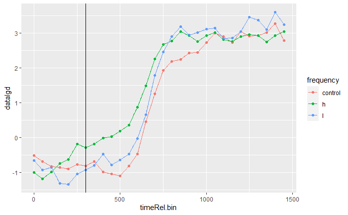

```r
#set up column with a 1 if they look at either of the two foils coded the same for experimental and control trials
f= bothpilot.f2$frequency == "control"
bothpilot.f2$FoilLk[f] = bothpilot.f2$ControlFoil1Lk[f]+bothpilot.f2$ControlFoil2Lk[f]
f= bothpilot.f2$frequency != "control"
bothpilot.f2$FoilLk[f] = bothpilot.f2$mismatch1LabelLk[f]+bothpilot.f2$mismatch2LabelLk[f]


expv <- bothpilot.f2 %>%
  filter(screen_index == 3 | screen_index == 4 ) %>%
  group_by(timeRel.bin ,frequency ,subjID,  targetLocation) %>%  ## grouping over just targetLocation Ok here, as combining foils
  summarize(sum_target = sum(targetLabelLk), sum_foil=sum(FoilLk), samples = length(targetLabelLk) )%>%
  mutate(Elog_t = log((sum_target+0.5)/(samples-sum_target+0.5)), Elog_f = log((sum_foil+0.5)/(samples-sum_foil+0.5)))%>%
  mutate(datalgd = Elog_t - Elog_f)%>%
  ungroup()
expv.agg = aggregate(data = expv,     datalgd ~ timeRel.bin + frequency + subjID + targetLocation, FUN = mean)
expv.agg2= aggregate(data = expv.agg, datalgd ~ timeRel.bin + frequency + subjID, FUN = mean)
expv.agg3= aggregate(data = expv.agg2, datalgd ~ timeRel.bin + frequency, FUN = mean)

p1= ggplot(expv.agg3, aes(x=timeRel.bin ,y=datalgd))
p1= p1+ geom_point(aes(color=frequency))
p1=p1+ geom_line(linetype="dashed", aes(color=frequency))
p1=p1+ geom_line(aes(color=frequency))
p1= p1 + geom_vline(xintercept= 300)

#p1= p1 + ylim(0.2,.6)
p1 = p1 + xlim(0,1450)
p1
```

```r
NA
NA
```

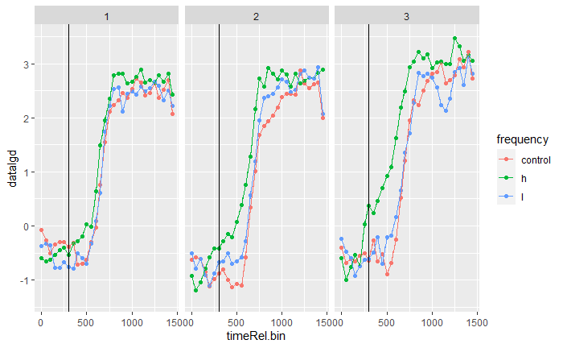

```r
#set up column with a 1 if they look at either of the two foils
f= bothpilot.f2$frequency == "control"
bothpilot.f2$FoilLk[f] = bothpilot.f2$ControlFoil1Lk[f]+bothpilot.f2$ControlFoil2Lk[f]
f= bothpilot.f2$frequency != "control"
bothpilot.f2$FoilLk[f] = bothpilot.f2$mismatch1LabelLk[f]+bothpilot.f2$mismatch2LabelLk[f]

expv <- bothpilot.f2 %>%
  filter(screen_index == 3 | screen_index == 4 ) %>%
  group_by(timeRel.bin ,frequency ,subjID,  targetLocation, block3) %>%
  summarize(sum_target = sum(targetLabelLk), sum_foil=sum(FoilLk), samples = length(targetLabelLk) )%>%
  mutate(Elog_t = log((sum_target+0.5)/(samples-sum_target+0.5)), Elog_f = log((sum_foil+0.5)/(samples-sum_foil+0.5)))%>%
  mutate(datalgd = Elog_t - Elog_f)%>%
  ungroup()
expv.agg = aggregate(data = expv,     datalgd ~ timeRel.bin + frequency + block3 + subjID + targetLocation, FUN = mean)
expv.agg2= aggregate(data = expv.agg, datalgd ~ timeRel.bin + frequency + block3 + subjID, FUN = mean)
expv.agg3= aggregate(data = expv.agg2, datalgd ~ timeRel.bin + frequency + block3 , FUN = mean)

p1= ggplot(expv.agg3, aes(x=timeRel.bin ,y=datalgd))
p1= p1+ geom_point(aes(color=frequency))
p1=p1+ geom_line(linetype="dashed", aes(color=frequency))
p1=p1+ geom_line(aes(color=frequency))
p1= p1 + geom_vline(xintercept= 300)

#p1= p1 + ylim(0.2,.6)
p1 = p1 + xlim(0,1450)
p1= p1+facet_wrap(~block3)

p1
```

```r
NA
NA
```

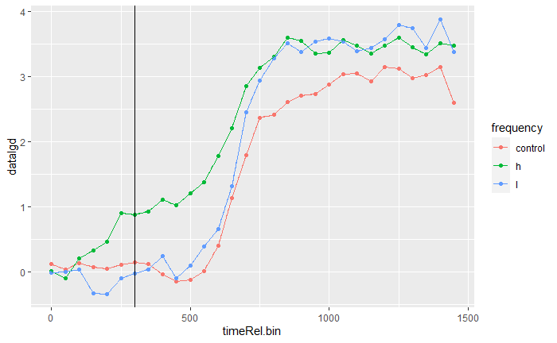

```r
#set up column with 1 if they look at mistmach1 or control foil1
f= bothpilot.f2$frequency == "control"
bothpilot.f2$FoilLk[f] = bothpilot.f2$ControlFoil1Lk[f]
f= bothpilot.f2$frequency != "control"
bothpilot.f2$FoilLk[f] = bothpilot.f2$mismatch1LabelLk[f]

bothpilot.f2$FoilLocation = NA
bothpilot.f2$FoilLocation[bothpilot.f2$frequency == "control"] =bothpilot.f2$Foil1Location[bothpilot.f2$frequency == "control"]
bothpilot.f2$FoilLocation[bothpilot.f2$frequency != "control"] =as.character(bothpilot.f2$mismatch1Location)[bothpilot.f2$frequency != "control"]
bothpilot.f2$FoilLocation= as.factor(bothpilot.f2$FoilLocation)

expv <- bothpilot.f2 %>%
  filter(screen_index == 3 | screen_index == 4 ) %>%
  group_by(timeRel.bin ,frequency ,subjID,  targetLocation, FoilLocation) %>%
  summarize(sum_target = sum(targetLabelLk), sum_foil=sum(FoilLk), samples = length(targetLabelLk) )%>%
  mutate(Elog_t = log((sum_target+0.5)/(samples-sum_target+0.5)), Elog_f = log((sum_foil+0.5)/(samples-sum_foil+0.5)))%>%
  mutate(datalgd = Elog_t - Elog_f)%>%
  ungroup()
expv.agg = aggregate(data = expv,     datalgd ~ timeRel.bin + frequency  + subjID + targetLocation + FoilLocation, FUN = mean)
expv.agg2= aggregate(data = expv.agg, datalgd ~ timeRel.bin + frequency  + subjID + targetLocation, FUN = mean)
expv.agg3= aggregate(data = expv.agg2, datalgd ~ timeRel.bin + frequency  + subjID, FUN = mean)
expv.agg4= aggregate(data = expv.agg3, datalgd ~ timeRel.bin + frequency  , FUN = mean)

p1= ggplot(expv.agg4, aes(x=timeRel.bin ,y=datalgd))
p1= p1+ geom_point(aes(color=frequency))
p1=p1+ geom_line(linetype="dashed", aes(color=frequency))
p1=p1+ geom_line(aes(color=frequency))
p1= p1 + geom_vline(xintercept= 300)
#p1= p1 + ylim(0.2,.6)
p1 = p1 + xlim(0,1450)

p1
```

```r
NA
NA
```

[figure not shown]

```r
expv <- bothpilot.f2 %>%
  filter(screen_index == 3 | screen_index == 4 ) %>%
  group_by(timeRel.bin ,frequency ,subjID,  targetLocation, FoilLocation, block3) %>%
  summarize(sum_target = sum(targetLabelLk), sum_foil=sum(FoilLk), samples = length(targetLabelLk) )%>%
  mutate(Elog_t = log((sum_target+0.5)/(samples-sum_target+0.5)), Elog_f = log((sum_foil+0.5)/(samples-sum_foil+0.5)))%>%
  mutate(datalgd = Elog_t - Elog_f)%>%
  ungroup()
expv.agg = aggregate(data = expv,     datalgd ~ timeRel.bin + frequency + block3 + subjID + targetLocation + FoilLocation, FUN = mean)
expv.agg2= aggregate(data = expv.agg, datalgd ~ timeRel.bin + frequency + block3  + subjID + targetLocation, FUN = mean)
expv.agg3= aggregate(data = expv.agg2, datalgd ~ timeRel.bin + frequency+ block3   + subjID, FUN = mean)
expv.agg4= aggregate(data = expv.agg3, datalgd ~ timeRel.bin + frequency+ block3   , FUN = mean)

#write.csv(expv.agg3, "onelinemismatch1.csv")

p1= ggplot(expv.agg4, aes(x=timeRel.bin ,y=datalgd))
p1= p1+ geom_point(aes(color=frequency))
p1=p1+ geom_line(linetype="dashed", aes(color=frequency))
p1=p1+ geom_line(aes(color=frequency))
p1= p1 + geom_vline(xintercept= 300)
#p1= p1 + ylim(0.2,.6)
p1 = p1 + xlim(0,1450)
p1= p1+facet_wrap(~block3)

p1
```

```r
NA
NA
```

# Statistical analyses:

## DV = preference for target over sum of the other two foils

```r
#set up column with a 1 if they look at either of the two foils
f= bothpilot.f2$frequency == "control"
bothpilot.f2$FoilLk[f] = bothpilot.f2$ControlFoil1Lk[f]+bothpilot.f2$ControlFoil2Lk[f]
f= bothpilot.f2$frequency != "control"
bothpilot.f2$FoilLk[f] = bothpilot.f2$mismatch1LabelLk[f]+bothpilot.f2$mismatch2LabelLk[f]
```

```r
expv.200_500.bothfoils <- bothpilot.f2 %>%
  filter(screen_index == 3 | screen_index == 4 & timeRel.bin >=200 & timeRel.bin <500   ) %>%
  group_by(frequency ,subjID,  targetLocation, trial, block3) %>%
  summarize(sum_target = sum(targetLabelLk), sum_foil=sum(FoilLk), samples = length(targetLabelLk) )%>%
  mutate(Elog_t = log((sum_target+0.5)/(samples-sum_target+0.5)), Elog_f = log((sum_foil+0.5)/(samples-sum_foil+0.5)))%>%
  mutate(datalgd = Elog_t - Elog_f)%>%
  ungroup()%>%
  data.frame()

expv.200_500.bothfoils = setContrasts(d=expv.200_500.bothfoils, condition=expv.200_500.bothfoils$frequency, baselevel="control")
expv.200_500.bothfoils = setContrasts(d=expv.200_500.bothfoils, condition=expv.200_500.bothfoils$targetLocation, baselevel="c")
expv.200_500.bothfoils = selectCenter(expv.200_500.bothfoils, list("block3"))

lmer.200_500.bothfoils = lmer(datalgd ~ 1
                    +(control_VS_h + control_VS_l)*block3.ct
                    + (c_VS_l + c_VS_r)
                    +block3.ct
                    +(control_VS_h+block3.ct||subjID), # note reduced slope
                    #+(control_VS_l|subjID), # can't have a slope for control vs Low- probably because less data here
                                        control = lmerControl(optimizer="bobyqa"),
                    data=expv.200_500.bothfoils,REML=FALSE)

summary(lmer.200_500.bothfoils)$coeff
```

[output not shown]

```r
expv.500_1450.bothfoils <- bothpilot.f2 %>%
  filter(screen_index == 3 | screen_index == 4 & timeRel.bin >=500 & timeRel.bin <1450   ) %>%
  group_by(frequency ,subjID,  targetLocation, trial, block3) %>%
  summarize(sum_target = sum(targetLabelLk), sum_foil=sum(FoilLk), samples = length(targetLabelLk) )%>%
  mutate(Elog_t = log((sum_target+0.5)/(samples-sum_target+0.5)), Elog_f = log((sum_foil+0.5)/(samples-sum_foil+0.5)))%>%
  mutate(datalgd = Elog_t - Elog_f)%>%
  ungroup()%>%
  data.frame()
expv.500_1450.bothfoils = setContrasts(d=expv.500_1450.bothfoils, condition=expv.500_1450.bothfoils$frequency, baselevel="control")
expv.500_1450.bothfoils = setContrasts(d=expv.500_1450.bothfoils, condition=expv.500_1450.bothfoils$targetLocation, baselevel="c")
expv.500_1450.bothfoils = selectCenter(expv.500_1450.bothfoils, list("block3"))

lmer.500_1450.bothfoils = lmer(datalgd ~ 1
                    +(control_VS_h + control_VS_l)*block3.ct
                    + (c_VS_l + c_VS_r)
                    +block3.ct
                    +(control_VS_h+block3.ct||subjID), # note reduced slope
                    #+(control_VS_l|subjID), # can't have a slope for control vs Low- probably because less data here
                                        control = lmerControl(optimizer="bobyqa"),
                    data=expv.500_1450.bothfoils,REML=FALSE)

summary(lmer.500_1450.bothfoils)$coeff
```

```
                          Estimate Std. Error         df     t value     Pr(>|t|)
(Intercept)             1.64773269  0.3581701   17.84209   4.6004193 2.267802e-04
control_VS_h            0.43677464  0.2010039   20.71458   2.1729657 4.153824e-02
control_VS_l            0.24673045  0.1491094 2434.08293   1.6546937 9.811558e-02
block3.ct              -0.01475876  0.1426634   17.25076  -0.1034516 9.187977e-01
c_VS_l                 -1.44292858  0.1191973 2432.71197 -12.1053774 8.501309e-33
c_VS_r                 -1.44794680  0.1191830 2431.08174 -12.1489326 5.156196e-33
control_VS_h:block3.ct  0.20620744  0.1442746 2436.94939   1.4292704 1.530547e-01
control_VS_l:block3.ct  0.02890429  0.1850783 2438.63072   0.1561733 8.759093e-01
```

## DV = preference for target over mismathc type 1 compared with foil over foil 1

```r
lmer.200_500.onefoil = lmer(datalgd ~ 1
                     +(control_VS_h+control_VS_l)*block3.ct
                    +(c_VS_l+ control_VS_l)
                    +(control_VS_h||subjID)
                    #+(control_VS_l|subjID), # can't have a slope for control vs Low- probably because less data here
                    +(1|targetFoilLocation),
                    control = lmerControl(optimizer="bobyqa"),
                    data=expv.200_500.onefoil,REML=FALSE)
summary(lmer.200_500.onefoil)$coeff
```

```
                           Estimate Std. Error          df    t value   Pr(>|t|)
(Intercept)             0.186853239 0.43082150    6.090744  0.4337138 0.67943767
control_VS_h            0.579129261 0.29618581   23.535808  1.9552904 0.06252380
control_VS_l           -0.179164427 0.16993865 2333.483809 -1.0542889 0.29185983
block3.ct               0.006924077 0.06444519 2447.280106  0.1074413 0.91444767
c_VS_l                  1.278816831 0.90885227    5.959022  1.4070679 0.20936424
control_VS_h:block3.ct  0.251261681 0.13841080 2457.827377  1.8153329 0.06959459
control_VS_l:block3.ct -0.007705455 0.17738116 2457.242994 -0.0434401 0.96535425
```

```r
lmer.500_1450.onefoil = lmer(datalgd ~ 1
                     +(control_VS_h+control_VS_l)*block3.ct
                    +(c_VS_l+ control_VS_l)
                    +(control_VS_h||subjID)
                    #+(control_VS_l|subjID), # can't have a slope for control vs Low- probably because less data here
                    +(1|targetFoilLocation),
                    control = lmerControl(optimizer="bobyqa"),
                    data=expv.500_1450.onefoil,REML=FALSE)
summary(lmer.500_1450.onefoil)$coeff
```

```
                           Estimate Std. Error          df    t value     Pr(>|t|)
(Intercept)             2.488667665 0.45284224   20.054781  5.4956614 2.202892e-05
control_VS_h            0.506652348 0.19750190   30.225971  2.5653036 1.550764e-02
control_VS_l           -0.076362806 0.15813654 1922.846991 -0.4828916 6.292277e-01
block3.ct              -0.009073832 0.06041619 2443.370357 -0.1501888 8.806281e-01
c_VS_l                  0.804956005 0.59025417    5.575982  1.3637447 2.251286e-01
control_VS_h:block3.ct  0.105733863 0.12989665 2446.290373  0.8139845 4.157331e-01
control_VS_l:block3.ct -0.056944806 0.16662923 2449.787061 -0.3417456 7.325717e-01
```

# particion into learners and non learners

```r
table(bothpilot.labPic$frequency, bothpilot.labPic$type_of_resp)
```

```
               errorControl errorControl-high errorControl-low match mismatch-type1 mismatch-type2 timedOut
  control_high            7                 0                0    62              2              0        5
  control_low             1                 0                0    69              0              0        6
  high                    0                 8                0   358             31             18       41
  low                     0                 0               11   179            185             35       46
```

Categorize them according to how they do with low frequency items, specifically how much they go for match over mistmatch-type1 which catpures learning versus overgenerlization

```r
tapply(overgen$contScore,overgen$subjID, mean )
```

```
     3467073      3473048      3491839      3502650      3517616      3517626      3528252      3528273
-125.2000000 -157.4666667 -126.8000000   -0.1333333 -108.8666667   -4.5333333 -120.2000000   -0.1333333
```

## plots

Plot 1- plotting proportion of looks to each for learners

```r
bothpilot.f2.withID.learners = subset(bothpilot.f2.withID, subjLearnerType == "learner")


table(bothpilot.f2.withID.learners.long$subjID)
```

```
3394859 3421453 3424063 3475213 3481518 3502663 3528246
 111490   94725  147905  131780   95160   83495   81595
```

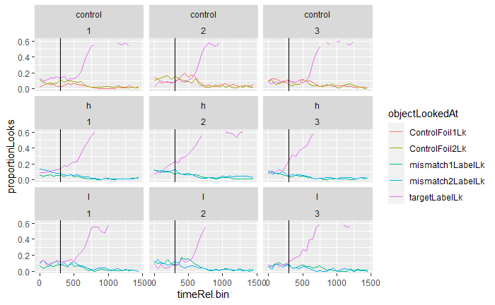

```r
bothpilot.f2.withID.learners.long = gather(bothpilot.f2.withID.learners, objectLookedAt, proportionLooks, targetLabelLk:mismatch2LabelLk, ControlFoil1Lk,ControlFoil2Lk )
bothpilot.f2.withID.learners.long$Location=NA

f=bothpilot.f2.withID.learners.long$objectLookedAt=="targetLabelLk"
bothpilot.f2.withID.learners.long$Location[f]=bothpilot.f2.withID.learners.long$targetLocation[f]

f=bothpilot.f2.withID.learners.long$objectLookedAt=="mismatch1LabelLk"
bothpilot.f2.withID.learners.long$Location[f]=bothpilot.f2.withID.learners.long$mismatch1Location[f]
f=bothpilot.f2.withID.learners.long$objectLookedAt=="mismatch2LabelLk"
bothpilot.f2.withID.learners.long$Location[f]=bothpilot.f2.withID.learners.long$mismatch2Location[f]

f=bothpilot.f2.withID.learners.long$objectLookedAt=="ControlFoil1Lk"
bothpilot.f2.withID.learners.long$Location[f]=bothpilot.f2.withID.learners.long$Foil1Location[f]
f=bothpilot.f2.withID.learners.long$objectLookedAt=="ControlFoil2Lk"
bothpilot.f2.withID.learners.long$Location[f]=bothpilot.f2.withID.learners.long$Foil2Location[f]


agg1= aggregate(data = subset(bothpilot.f2.withID.learners.long, screen_index==3|screen_index==4),
                             proportionLooks~ objectLookedAt+timeRel.bin + frequency + block3 + subjID +Location, FUN= mean)
agg2= aggregate(data = agg1, proportionLooks~ objectLookedAt +timeRel.bin + frequency+ block3  + subjID, FUN= mean)
agg3= aggregate(data = agg2, proportionLooks~ objectLookedAt+timeRel.bin + frequency + block3, FUN= mean)

#write.csv(agg3, "threeLines.csv")

p2= ggplot(agg3, aes(x=timeRel.bin, y=proportionLooks)) + geom_line(aes(color= objectLookedAt))
p2= p2 + geom_vline(xintercept= 300)
p2= p2 + ylim(0,.6)
p2 = p2 + xlim(0,1450)
p2= p2+facet_wrap(~frequency+block3)
p2
```

```r
#log_odd<-function(p) {log(p/(1-p))}
```

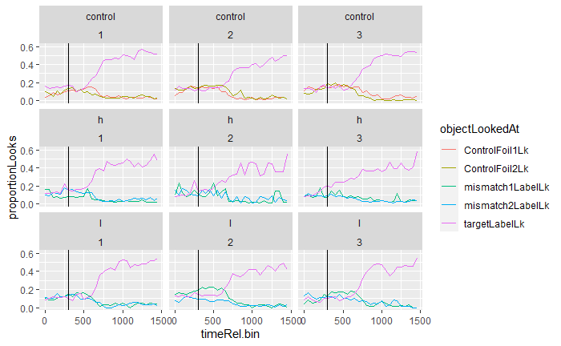

```r
bothpilot.f2.withID.overgens = subset(bothpilot.f2.withID, subjLearnerType == "overgen")


bothpilot.f2.withID.overgens.long = gather(bothpilot.f2.withID.overgens, objectLookedAt, proportionLooks, targetLabelLk:mismatch2LabelLk, ControlFoil1Lk,ControlFoil2Lk )
bothpilot.f2.withID.overgens.long$Location=NA

f=bothpilot.f2.withID.overgens.long$objectLookedAt=="targetLabelLk"
bothpilot.f2.withID.overgens.long$Location[f]=bothpilot.f2.withID.overgens.long$targetLocation[f]

f=bothpilot.f2.withID.overgens.long$objectLookedAt=="mismatch1LabelLk"
bothpilot.f2.withID.overgens.long$Location[f]=bothpilot.f2.withID.overgens.long$mismatch1Location[f]
f=bothpilot.f2.withID.overgens.long$objectLookedAt=="mismatch2LabelLk"
bothpilot.f2.withID.overgens.long$Location[f]=bothpilot.f2.withID.overgens.long$mismatch2Location[f]

f=bothpilot.f2.withID.overgens.long$objectLookedAt=="ControlFoil1Lk"
bothpilot.f2.withID.overgens.long$Location[f]=bothpilot.f2.withID.overgens.long$Foil1Location[f]
f=bothpilot.f2.withID.overgens.long$objectLookedAt=="ControlFoil2Lk"
bothpilot.f2.withID.overgens.long$Location[f]=bothpilot.f2.withID.overgens.long$Foil2Location[f]


agg1= aggregate(data = subset(bothpilot.f2.withID.overgens.long, screen_index==3|screen_index==4),
                             proportionLooks~ objectLookedAt+timeRel.bin + frequency + block3 + subjID +Location, FUN= mean)
agg2= aggregate(data = agg1, proportionLooks~ objectLookedAt +timeRel.bin + frequency+ block3  + subjID, FUN= mean)
agg3= aggregate(data = agg2, proportionLooks~ objectLookedAt+timeRel.bin + frequency + block3, FUN= mean)

#write.csv(agg3, "threeLines.csv")

p2= ggplot(agg3, aes(x=timeRel.bin, y=proportionLooks)) + geom_line(aes(color= objectLookedAt))
p2= p2 + geom_vline(xintercept= 300)
p2= p2 + ylim(0,.6)
p2 = p2 + xlim(0,1450)
p2= p2+facet_wrap(~frequency+block3)
p2
```

```r
#log_odd<-function(p) {log(p/(1-p))}
```

checking against eva values

| subjID | frequency | errorControl-low | match | mismatch-type1 | mismatch-type2 | timedOut |
| --- | --- | --- | --- | --- | --- | --- |
| 3394859 | low | NA | 16 | 3 | 1 | 4 |
| 3421453 | low | NA | 16 | 1 | 3 | 4 |
| 3424063 | low | NA | 22 | NA | NA | 2 |
| 3430836 | low | NA | 6 | 13 | 1 | 4 |
| 3467073 | low | 4 | 3 | 15 | NA | 2 |
| 3473048 | low | NA | NA | 24 | NA | NA |
| 3475213 | low | NA | 14 | 9 | NA | 1 |
| 3481518 | low | NA | 19 | 3 | 2 | NA |
| 3491839 | low | 4 | 5 | 12 | 2 | 1 |
| 3502047 | low | NA | 4 | NA | NA | 20 |

[output cut: 9 more lines]

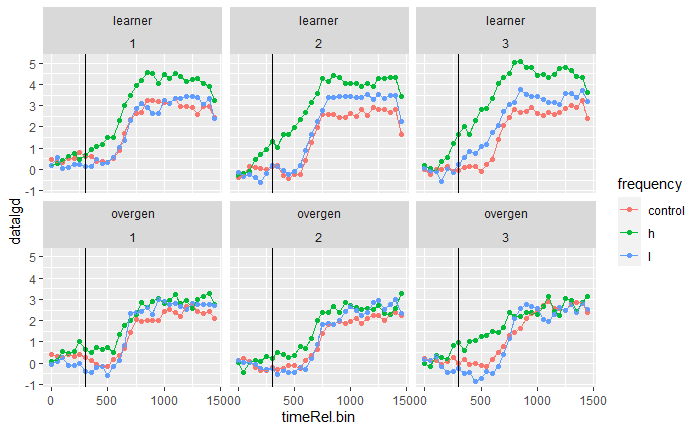

```r
#set up column with 1 if they look at mistmach1 or control foil1
f= bothpilot.f2.withID$frequency == "control"
bothpilot.f2.withID$FoilLk[f] = bothpilot.f2.withID$ControlFoil1Lk[f]
f= bothpilot.f2.withID$frequency != "control"
bothpilot.f2.withID$FoilLk[f] = bothpilot.f2.withID$mismatch1LabelLk[f]

bothpilot.f2.withID$FoilLocation = NA
bothpilot.f2.withID$FoilLocation[bothpilot.f2.withID$frequency == "control"] =bothpilot.f2.withID$Foil1Location[bothpilot.f2.withID$frequency == "control"]
bothpilot.f2.withID$FoilLocation[bothpilot.f2.withID$frequency != "control"] =as.character(bothpilot.f2.withID$mismatch1Location)[bothpilot.f2.withID$frequency != "control"]
bothpilot.f2.withID$FoilLocation= as.factor(bothpilot.f2.withID$FoilLocation)

expv <- bothpilot.f2.withID %>%
  filter(screen_index == 3 | screen_index == 4 ) %>%
  filter(subjLearnerType!="ambig") %>%

  group_by(timeRel.bin ,frequency ,subjID,  targetLocation, FoilLocation, block3, subjLearnerType) %>%
  summarize(sum_target = sum(targetLabelLk), sum_foil=sum(FoilLk), samples = length(targetLabelLk) )%>%
  mutate(Elog_t = log((sum_target+0.5)/(samples-sum_target+0.5)), Elog_f = log((sum_foil+0.5)/(samples-sum_foil+0.5)))%>%
  mutate(datalgd = Elog_t - Elog_f)%>%
  ungroup()
expv.agg = aggregate(data = expv,     datalgd ~ timeRel.bin + frequency + block3 +subjLearnerType+ subjID + targetLocation + FoilLocation, FUN = mean)
expv.agg2= aggregate(data = expv.agg, datalgd ~ timeRel.bin + frequency + block3 +subjLearnerType + subjID + targetLocation, FUN = mean)
expv.agg3= aggregate(data = expv.agg2, datalgd ~ timeRel.bin + frequency+ block3  +subjLearnerType + subjID, FUN = mean)
expv.agg4= aggregate(data = expv.agg3, datalgd ~ timeRel.bin + frequency+ block3  +subjLearnerType , FUN = mean)

#write.csv(expv.agg3, "onelinemismatch1.csv")

p1= ggplot(expv.agg4, aes(x=timeRel.bin ,y=datalgd))
p1= p1+ geom_point(aes(color=frequency))
p1=p1+ geom_line(linetype="dashed", aes(color=frequency))
p1=p1+ geom_line(aes(color=frequency))
p1= p1 + geom_vline(xintercept= 300)
#p1= p1 + ylim(0.2,.6)
p1 = p1 + xlim(0,1450)
p1= p1+facet_wrap(~subjLearnerType+block3)

p1
```

```r
NA
NA
```

```r
# mistmatch1 versus mismatch2
#set up column with 1 if they look at mistmach1 or control foil1

bothpilot.f2.withID$mismatch1LabelLk
```

[output not shown]

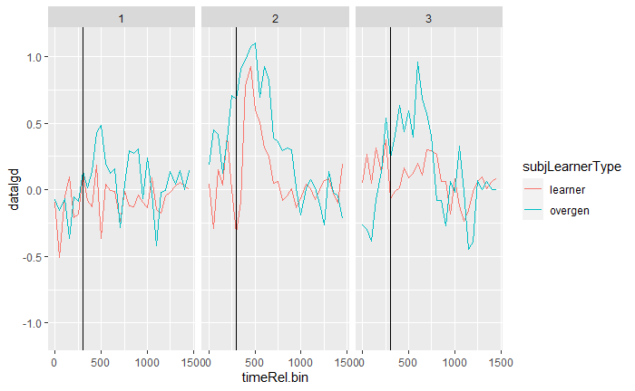

```r
expv <- bothpilot.f2.withID %>%
  filter(screen_index == 3 | screen_index == 4 ) %>%
  filter(subjLearnerType!="ambig") %>%
  filter(frequency=="l") %>%

  group_by(timeRel.bin ,frequency ,subjID,  mismatch2Location, mismatch1Location, block3, subjLearnerType) %>%
  summarize(sum_mismatch1 = sum(mismatch1LabelLk), sum_mismatch2=sum(mismatch2LabelLk), samples = length(mismatch1LabelLk) )%>%
  mutate(Elog_t = log((sum_mismatch1+0.5)/(samples-sum_mismatch1+0.5)), Elog_f = log((sum_mismatch2+0.5)/(samples-sum_mismatch2+0.5)))%>%
  mutate(datalgd = Elog_t - Elog_f)%>%
  ungroup()
expv.agg = aggregate(data = expv,     datalgd ~ timeRel.bin  + block3 +subjLearnerType+ subjID + mismatch1Location + mismatch2Location, FUN = mean)
expv.agg2= aggregate(data = expv.agg, datalgd ~ timeRel.bin + block3 +subjLearnerType + subjID +  mismatch1Location, FUN = mean)
expv.agg3= aggregate(data = expv.agg2, datalgd ~ timeRel.bin+ block3  +subjLearnerType + subjID, FUN = mean)
expv.agg4= aggregate(data = expv.agg3, datalgd ~ timeRel.bin+ block3  +subjLearnerType , FUN = mean)

expv.agg4$block3=as.factor(expv.agg4$block3)
p1= ggplot(expv.agg4, aes(x=timeRel.bin ,y=datalgd))
#p1= p1+ geom_point(aes(color=subjLearnerType))
#p1=p1+ geom_line(linetype="dashed", aes(color=subjLearnerType))
p1=p1+ geom_line(aes(color=subjLearnerType))
p1= p1 + geom_vline(xintercept= 300)
#p1= p1 + ylim(0.2,.6)
p1 = p1 + xlim(0,1450)
p1= p1+facet_wrap(~block3)

p1
```

```r
NA
NA
```